# Project Traffic Violations

Naixin Zhu

2/28/2019

# Prepare Data for Regression

## Load the data

```r
Traffic_Violations <- data.frame(read.csv("C:\\Users\\naixi\\OneDrive\\_____GWU ECON PHD_____\\__2019 Spring__\\Intro to Data Science\\Project 1\\Data\\Traffic_Violations.csv", header = TRUE))

TV1 <- Traffic_Violations
#View(TV1)
```

## Unique values of each variable

```r
library(dplyr)
apply(TV1, 2, function(x) length(unique(x)))
```

```
##            Date.Of.Stop            Time.Of.Stop                  Agency
##                    2306                    1440                       1
##               SubAgency             Description                Location
##                       8                   12633                  187000
##                Latitude               Longitude                Accident
##                  272037                   41061                       1
##                   Belts         Personal.Injury         Property.Damage
##                       2                       2                       2
##                   Fatal      Commercial.License                  HAZMAT
##                       2                       2                       2
##      Commercial.Vehicle                 Alcohol               Work.Zone
##                       2                       2                       2
##                   State             VehicleType                    Year
##                      70                      33                     312
##                    Make                   Model                   Color
##                    3552                   17563                      28
##          Violation.Type                  Charge                 Article
##                       4                    1029                       3
## Contributed.To.Accident                    Race                  Gender
##                       2                       6                       3
##             Driver.City            Driver.State                DL.State
##                    7296                      69                      71
##             Arrest.Type             Geolocation
##                      19                  633936
```

```r
unique(TV1$Race)
```

```
## [1] BLACK           WHITE           HISPANIC        ASIAN
## [5] OTHER           NATIVE AMERICAN
## Levels: ASIAN BLACK HISPANIC NATIVE AMERICAN OTHER WHITE
```

```r
unique(TV1$Arrest.Type)
```

```
##  [1] A - Marked Patrol
##  [2] Q - Marked Laser
##  [3] O - Foot Patrol
##  [4] B - Unmarked Patrol
##  [5] M - Marked (Off-Duty)
##  [6] E - Marked Stationary Radar
##  [7] L - Motorcycle
##  [8] R - Unmarked Laser
##  [9] S - License Plate Recognition
## [10] D - Unmarked VASCAR
## [11] G - Marked Moving Radar (Stationary)
## [12] I - Marked Moving Radar (Moving)
## [13] H - Unmarked Moving Radar (Stationary)
## [14] F - Unmarked Stationary Radar
## [15] P - Mounted Patrol
## [16] C - Marked VASCAR
## [17] J - Unmarked Moving Radar (Moving)
## [18] N - Unmarked (Off-Duty)
## [19] K - Aircraft Assist
## 19 Levels: A - Marked Patrol B - Unmarked Patrol ... S - License Plate Recognition
```

```r
# Take a closer look at the year varaibles since it has too many unique values
unique(TV1$Year)
```

```
##   [1] 2008 2001 1998 2015 2013 1993 2003 2005 1996 2004 2002 2009 2000 1991
##  [15] 2012   NA 2011 2006 2007 1997 1999 1994 2017 2016 2010 2014 1995 1990
##  [29]    0 3003 1988 1992  128 1985 1989 1987 1986 1982 2018 1983 1003 1975
##  [43] 2021 1972 2202 1981 1977 1976 1969 1973 1984 9999 1980 1197 2103 1974
##  [57] 2022 5338 1007 1900 2914 3013 1978 2077 1111 4452 2916 2019 2031 2207
##  [71]    6 1958 1010 2911 1966 1979 1005 2104 2941 1013 1970 2500 2919 1012
##  [85]  211 1965 4200 1017 5300 4046 2992 1776 1729 2596 5384 2105 2258 8560
##  [99] 2024 1001 6338 1967 2998 2502 5005 5257 1299 1971 1071 3574 1953 2917
## [113]  205 2200 1076 2088 1195 1196 1968 2773 2915 2912 2051 9035 1199   95
## [127] 1957 5843 2997 7575 9624 4313    8 5441 1936 4209 3244 1964 2096 5772
## [141] 9510 1186 2112 5015 1741 1015 2066 1879 6838 2025 2044 3940 2097  277
## [155] 2102 1006 2050 2201 1194 7247 2793 1016 4112 2205 2209 2099 1963 1902
## [169] 2483 2151 5199 8008 8042 4004 2055 1959 6856 2203 5709 2511 1616 2913
## [183]   12 5470 3008 9382 2206 2101 2171 2204 2110 2986 2996 2576    9 2054
## [197] 9219 7104 9705 5603 1952    4 5265 9013 1885 5397 2621 2373 4515 7513
## [211] 9563 1865 3096 2020 2106 1930 3435 3517 3104 6153 2993 1962 2033 2991
## [225] 2090 8739 2023 1008 3201 2994 3776 2331 1931 2040 3002 3014 2091 5256
## [239] 7007 3005   97 1004 4122 1894 3113 1887 6874 1929 2208 3837 2995 6078
## [253] 4146 1899 9463 2085 1146  707 2999 1026 6580 3007 9867 1665 5004 1886
## [267] 5450 5237 1088 2452 1932 1014 2442 1009 1951 1920 2100 2295 3510  798
## [281] 4706 7266 3503 1925 1411 3790 3010 1145 1478 3111 3886 5421   10 1312
## [295] 2901 1549 1357 2179   11 8615  220  620 5456 3004 3861 3373 3316    5
## [309]   93 4580 3802 1368
```

```r
group_year <- TV1 %>% group_by(Year) %>% summarise(count = n())
group_year <- group_year[with(group_year, order(-count)),]
group_year
```

```
## # A tibble: 312 x 2
##     Year count
##    <int> <int>
##  1  2006 80080
##  2  2007 79299
##  3  2005 78297
##  4  2004 76986
##  5  2003 73713
##  6  2008 70497
##  7  2012 69235
##  8  2002 67402
##  9  2011 65332
## 10  2013 64674
## # ... with 302 more rows
```

```r
TV_Y2015 <- subset(TV1, Year == 2015)
```

## Change categorical variables to binary

To further prepare for the logistic regression for the cross-sectional data in 2015, we change the “Yes” and “No” responses to 1 and 0, respectively.

```r
library(dplyr)
TV2 <- mutate(TV_Y2015, vio_type_citation = ifelse(Violation.Type == "Citation", 1, 0)) %>%
       mutate(vio_type_warning = ifelse(Violation.Type == "Warning", 1, 0)) %>%
       mutate(vio_type_SERO = ifelse(Violation.Type == "SERO", 1, 0)) %>%
       mutate(vio_type_ESERO = ifelse(Violation.Type == "ESERO", 1, 0))%>%
       mutate(Male = ifelse(Gender == "M", 1, 0))%>%
       mutate(Female = ifelse(Gender == "F", 1, 0))%>%
       mutate(Alcohol = ifelse(Alcohol == "Yes", 1, 0))%>%
       mutate(Belts = ifelse(Belts == "Yes", 1, 0))%>%
       mutate(Black = ifelse(Race == "BLACK", 1, 0))%>%
       mutate(White = ifelse(Race == "WHITE", 1, 0))%>%
       mutate(Hispanic = ifelse(Race == "HISPANIC", 1, 0))%>%
       mutate(Asian = ifelse(Race == "ASIAN", 1, 0))%>%
       mutate(Native_American = ifelse(Race == "NATIVE AMERICAN", 1, 0))%>%
       mutate(Other_race = ifelse(Race == "OTHER", 1, 0))%>%
       mutate(Personal.Injury = ifelse(Personal.Injury == "Yes", 1, 0))%>%
       mutate(Property.Damage = ifelse(Property.Damage == "Yes", 1, 0))%>%
       mutate(Fatal = ifelse(Fatal == "Yes", 1, 0))%>%
       mutate(Commercial.License = ifelse(Commercial.License == "Yes", 1, 0))%>%
       mutate(Commercial.Vehicle = ifelse(Commercial.Vehicle == "Yes", 1, 0))%>%
       mutate(HAZMAT = ifelse(HAZMAT == "Yes", 1, 0))%>%
       mutate(Work.Zone = ifelse(Work.Zone == "Yes", 1, 0))
```

## Cluster at location level and change binary to ratio variables.

According to Kaggle website (https://www.kaggle.com/rounak041993/traffic-violations-in-maryland-county), location of the violation is usually an address or intersection. There are in total 15,646 locations in the data in year 2015, which ensures we have enough data points to run regression after clustering.

```r
length(unique(TV2$Location))
```

```
## [1] 15646
```

```r
# https://stackoverflow.com/questions/29255473/most-frequent-value-mode-by-group
Mode <- function(x) {
  ux <- unique(x)
  ux[which.max(tabulate(match(x, ux)))]
}

TV3 <- TV2 %>%
select(Location, Belts, Alcohol, Male, Female, Personal.Injury, Property.Damage, Fatal, Commercial.License, Commercial.Vehicle, HAZMAT, vio_type_citation, vio_type_warning, vio_type_SERO, vio_type_ESERO, Black, White, Hispanic, Asian, Native_American, Other_race, Work.Zone, SubAgency) %>%
group_by(Location) %>%
summarise( Belts = sum(Belts)/n(), Alcohol = sum(Alcohol)/n(),
           Personal.Injury = sum(Personal.Injury)/n(),
           Property.Damage = sum(Property.Damage)/n(),
           Fatal = sum(Fatal)/n(),
           Commercial.License = sum(Commercial.License)/n(),
           Commercial.Vehicle = sum(Commercial.Vehicle)/n(),
           HAZMAT = sum(HAZMAT)/n(),
           vio_type_warning = sum(vio_type_warning)/n(),
           vio_type_ESERO = sum(vio_type_ESERO)/n(),
           vio_type_SERO = sum(vio_type_SERO)/n(),
           vio_type_citation = sum(vio_type_citation)/n(),
           Black = sum(Black)/n(), White = sum(White)/n(),
           Hispanic = sum(Hispanic)/n(),
           Native_American = sum(Native_American)/n(),
           Asian = sum(Asian)/n(),
           Other_race = sum(Other_race)/n(),
           Work.Zone = sum(Work.Zone)/n(),
           Male = sum(Male)/n(),
           Female = 1-Male,
           not_warning = 1 - vio_type_warning,
           not_citation = 1 - vio_type_citation,
           not_ESERO = 1 - vio_type_ESERO,
           not_SERO = 1 - vio_type_SERO,
           SubAgency = Mode(SubAgency))


sapply(TV3, class)
```

```
##           Location              Belts            Alcohol
##           "factor"          "numeric"          "numeric"
##    Personal.Injury    Property.Damage              Fatal
##          "numeric"          "numeric"          "numeric"
## Commercial.License Commercial.Vehicle             HAZMAT
##          "numeric"          "numeric"          "numeric"
##   vio_type_warning     vio_type_ESERO      vio_type_SERO
##          "numeric"          "numeric"          "numeric"
##  vio_type_citation              Black              White
##          "numeric"          "numeric"          "numeric"
##           Hispanic    Native_American              Asian
##          "numeric"          "numeric"          "numeric"
##         Other_race          Work.Zone               Male
##          "numeric"          "numeric"          "numeric"
##             Female        not_warning       not_citation
##          "numeric"          "numeric"          "numeric"
##          not_ESERO           not_SERO          SubAgency
##          "numeric"          "numeric"           "factor"
```

## Get quick descriptive stats of the clustered dataset

```r
library(Hmisc)
Hmisc::describe(TV3)
```

```
## TV3
##
##  27  Variables      15646  Observations
## ---------------------------------------------------------------------------
## Location
##        n  missing distinct
##    15646        0    15646
##
## lowest : 1-495E / EXIT 30B 29 COLESVILLE RD 100 BLK RT193                      100 BLK WB BRIGHTON DAM RD         100 BRIGHTON DAM RD                100 EDISON PARK DR
## highest: YELLOWSTONE WAY @ REDLAND RD       YELLOWSTONE WAY RT ON CHIEFTIAN    ZION RD @ BLUE MASH NATURE TRAIL   ZION RD NORTH OF RIGGS RD          ZION RD/BLUE MASH NATURE TRAIL
## ---------------------------------------------------------------------------
## Belts
##        n  missing distinct     Info     Mean      Gmd      .05      .10
##    15646        0       44    0.107  0.03162  0.06123        0        0
##      .25      .50      .75      .90      .95
##        0        0        0        0        0
##
## lowest : 0.00000000 0.01960784 0.04347826 0.05882353 0.07500000
## highest: 0.90000000 0.91666667 0.93750000 0.96000000 1.00000000
## ---------------------------------------------------------------------------
## Alcohol
##         n   missing  distinct      Info      Mean       Gmd
##     15646         0         5     0.001 0.0003162 0.0006323
##
## Value      0.0000000 0.5000000 0.7142857 0.7333333 1.0000000
## Frequency      15640         1         1         1         3
## Proportion         1         0         0         0         0
## ---------------------------------------------------------------------------
## Personal.Injury
##        n  missing distinct     Info     Mean      Gmd      .05      .10
##    15646        0       24    0.041  0.01259  0.02486        0        0
##      .25      .50      .75      .90      .95
##        0        0        0        0        0
##
## lowest : 0.00000000 0.04347826 0.06250000 0.07692308 0.09090909
## highest: 0.80000000 0.83333333 0.85714286 0.91666667 1.00000000
## ---------------------------------------------------------------------------
## Property.Damage
##        n  missing distinct     Info     Mean      Gmd      .05      .10
##    15646        0       25    0.057  0.01718  0.03376        0        0
```

[output cut: 187 more lines]

```
##
## Value          1
## Frequency  15646
## Proportion     1
## ---------------------------------------------------------------------------
## SubAgency
##        n  missing distinct
##    15646        0        7
##
## 1st district, Rockville (2140, 0.137), 2nd district, Bethesda (3266,
## 0.209), 3rd district, Silver Spring (2692, 0.172), 4th district, Wheaton
## (2973, 0.190), 5th district, Germantown (2091, 0.134), 6th district,
## Gaithersburg / Montgomery Village (1767, 0.113), Headquarters and Special
## Operations (717, 0.046)
## ---------------------------------------------------------------------------
```

## Cross-tab categorical variables

```r
library(expss)
# https://cran.r-project.org/web/packages/expss/vignettes/tables-with-labels.html


TV4 = apply_labels(TV_Y2015, Gender = c("Male" = "M",
                             "Female" = "F"),
                   Fatal = c("Fatal" = "Yes",
                             "Not Fatal" = "No"),
                   Alcohol = c("Alcohol"= "Yes",
                             "Non-Alcohol" = "No"),
                   Belts = c("Belts"= "Yes",
                             "No Belts" = "No"))
cro(TV4$Violation.Type, list(total(), TV4$Gender, TV4$Race, TV4$Fatal, TV4$Alcohol, TV4$Belts))
```

|  | #Total | Female | Male | U | ASIAN | BLACK | HISPANIC | NATIVE AMERICAN | OTHER | WHITE | Not Fatal | Fatal | Non-Alcohol | Alcohol | No Belts | Belts |
| --- | --- | --- | --- | --- | --- | --- | --- | --- | --- | --- | --- | --- | --- | --- | --- | --- |
| TV4$Violation.Type |  |  |  |  |  |  |  |  |  |  |  |  |  |  |  |  |
| Citation | 18753 | 6483 | 12259 | 11 | 1264 | 6259 | 3272 | 41 | 1241 | 6676 | 18751 | 2 | 18714 | 39 | 17816 | 937 |
| ESERO | 733 | 203 | 530 |  | 65 | 214 | 190 | 5 | 29 | 230 | 733 |  | 733 |  | 716 | 17 |
| SERO |  |  |  |  |  |  |  |  |  |  |  |  |  |  |  |  |
| Warning | 23956 | 9660 | 14275 | 21 | 2068 | 6764 | 3372 | 69 | 1722 | 9961 | 23956 |  | 23956 |  | 23342 | 614 |
| #Total cases | 43442 | 16346 | 27064 | 32 | 3397 | 13237 | 6834 | 115 | 2992 | 16867 | 43440 | 2 | 43403 | 39 | 41874 | 1568 |

## Singel-varaible bar charts for data in 2015

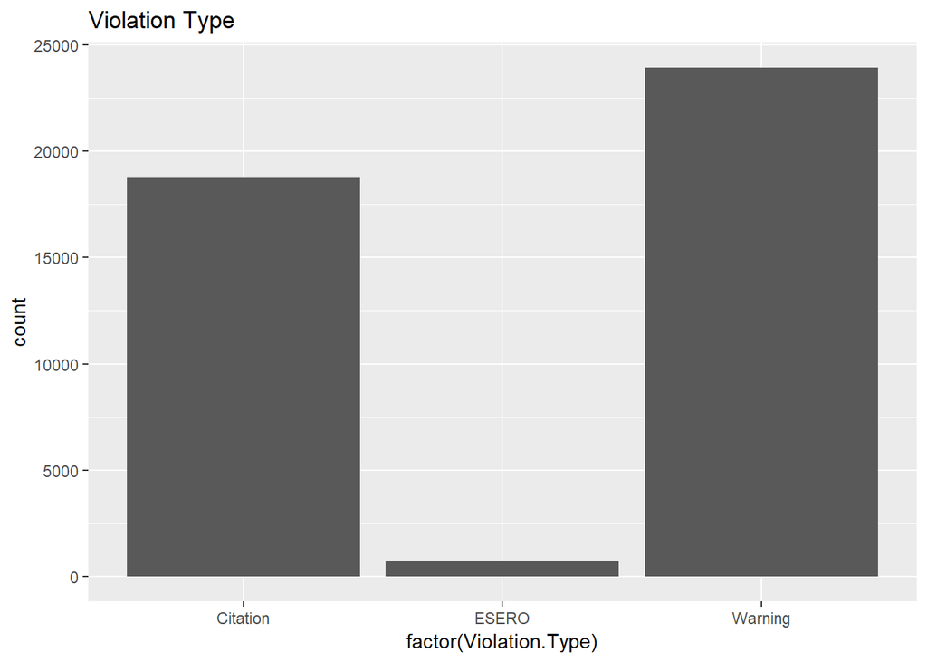

```r
######################## Single variabels ####################################
library(ggplot2)
library(gridExtra)
a <- ggplot(TV_Y2015, aes(factor(Violation.Type))) + geom_bar() + ggtitle("Violation Type")
a
```

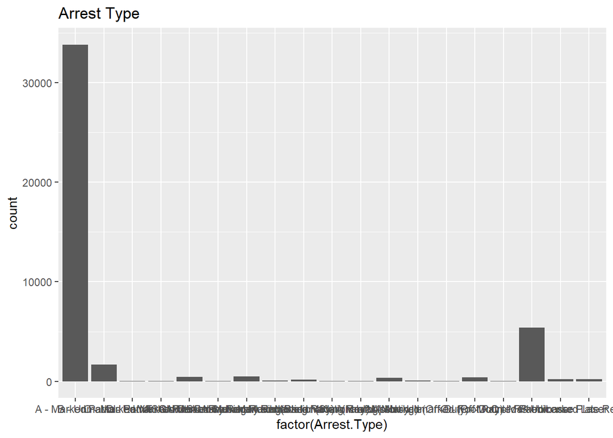

```r
b <- ggplot(TV_Y2015, aes(factor(Arrest.Type))) + geom_bar() + ggtitle("Arrest Type")
b
```

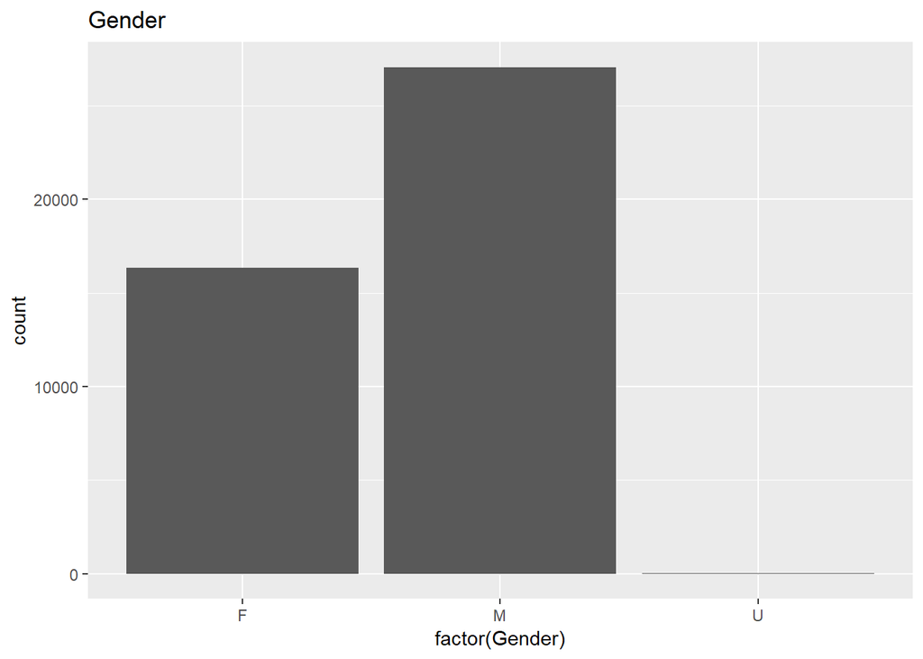

```r
c <- ggplot(TV_Y2015, aes(factor(Gender))) + geom_bar() + ggtitle("Gender")
c
```

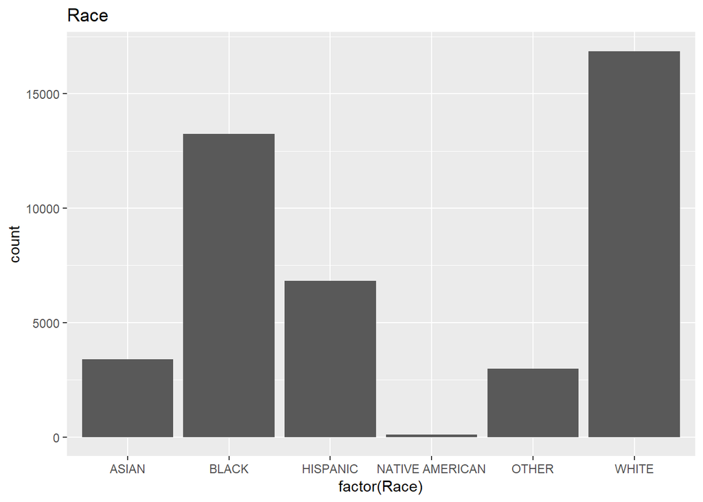

```r
d <- ggplot(TV_Y2015, aes(factor(Race))) + geom_bar() + ggtitle("Race")
d
```

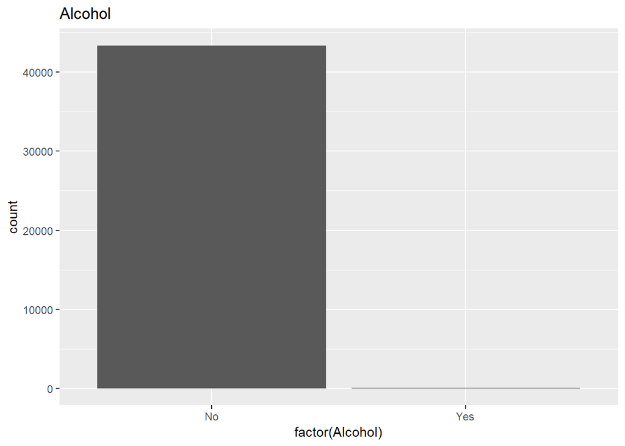

```r
e <- ggplot(TV_Y2015, aes(factor(Alcohol))) + geom_bar() + ggtitle("Alcohol")
e
```

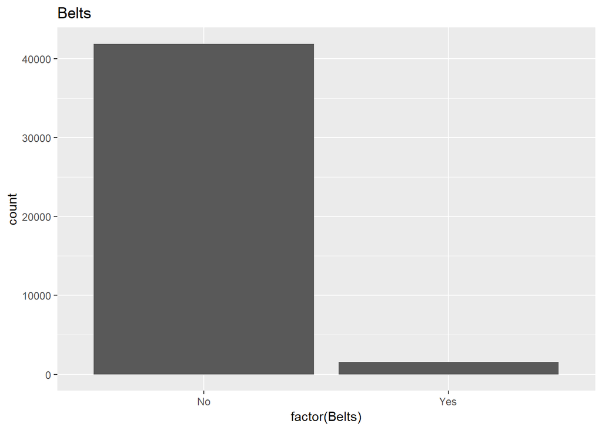

```r
f <- ggplot(TV_Y2015, aes(factor(Belts))) + geom_bar() + ggtitle("Belts")
f
```

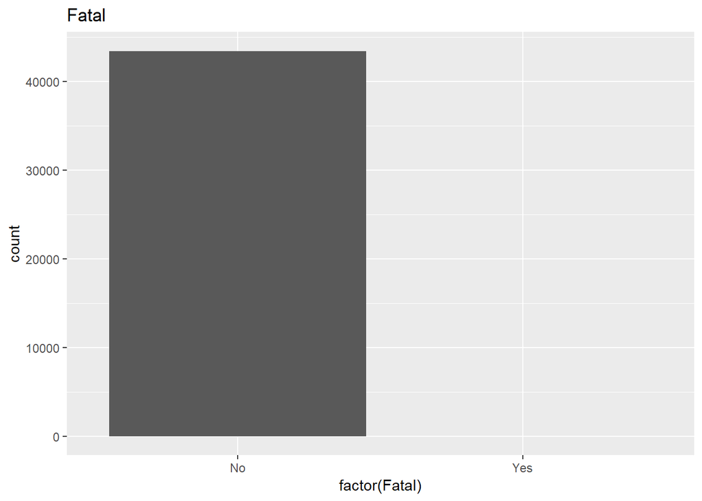

```r
g <- ggplot(TV_Y2015, aes(factor(Fatal))) + geom_bar() + ggtitle("Fatal")
g
```

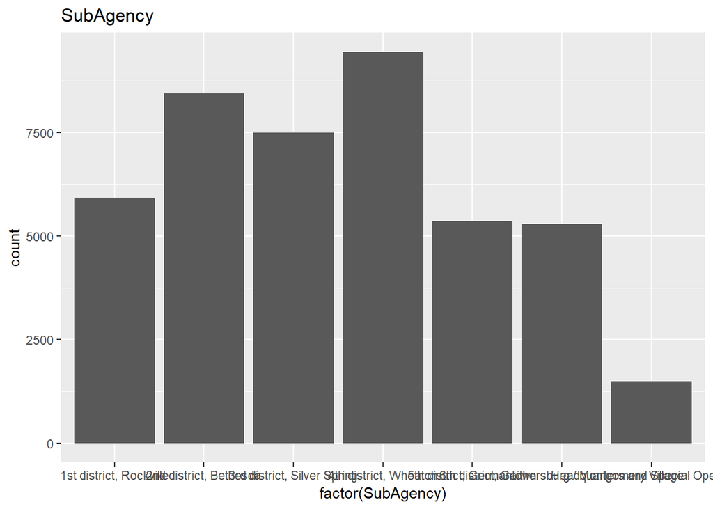

```r
h <- ggplot(TV_Y2015, aes(factor(SubAgency))) + geom_bar() + ggtitle("SubAgency")
h
```

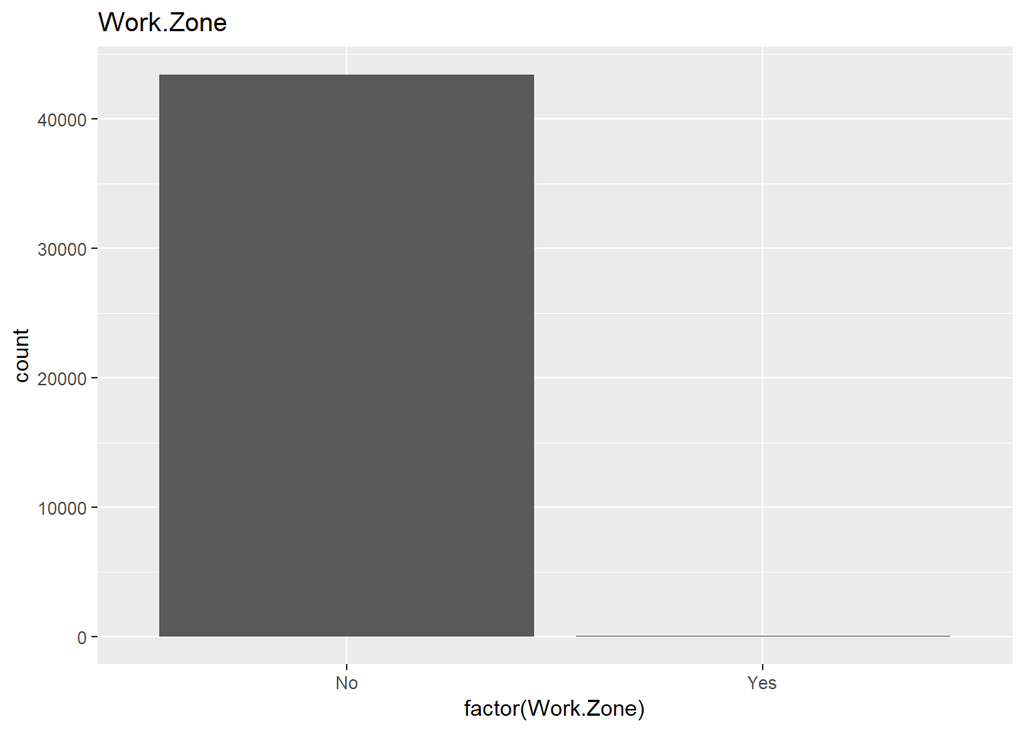

```r
i <- ggplot(TV_Y2015, aes(factor(Work.Zone))) + geom_bar() + ggtitle("Work.Zone")
i
```

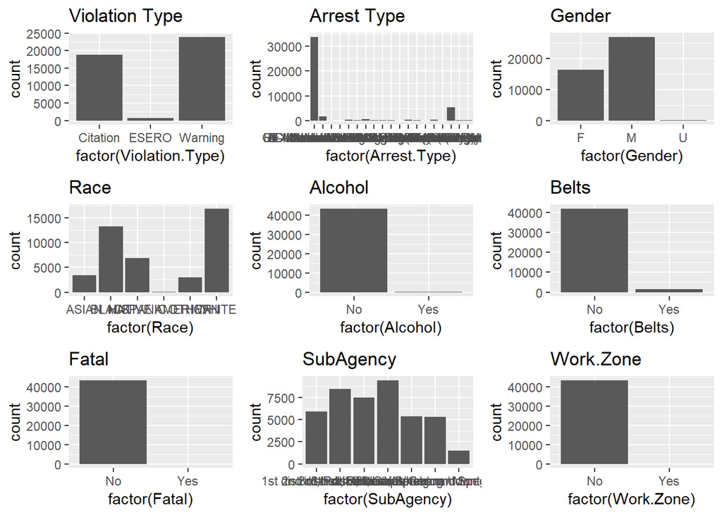

```r
grid.arrange(a, b, c, d, e, f, g, h, i, ncol=3)
```

## Two-variables bar charts based on data in 2015

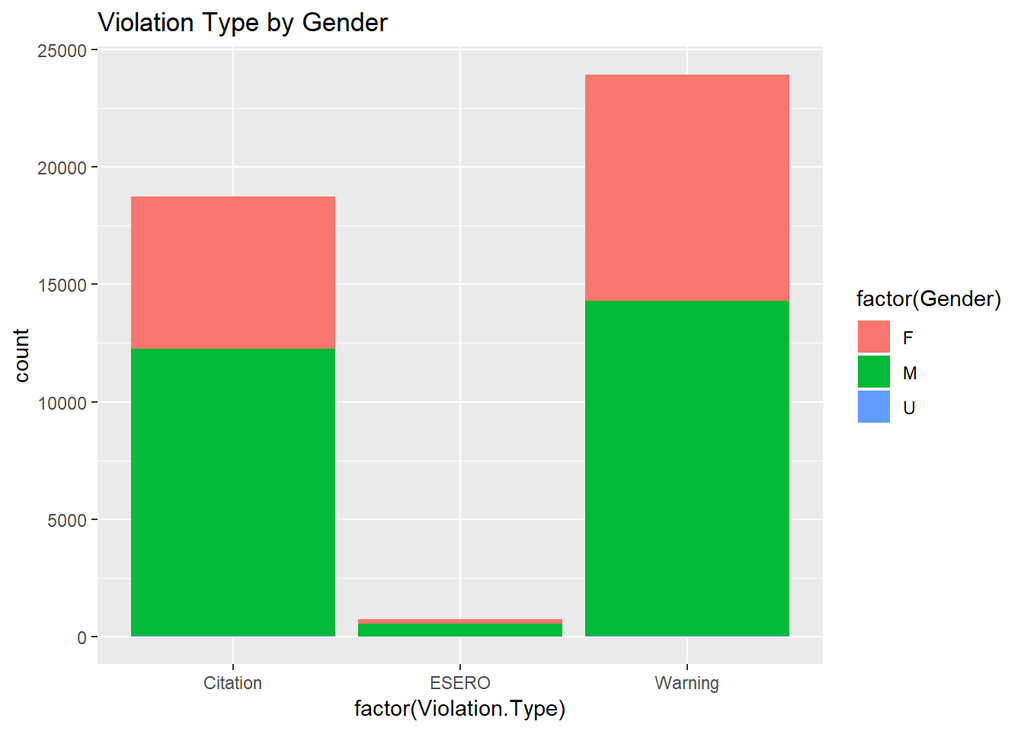

```r
                                                                                                                       a1 <- a + geom_bar(aes(fill = factor(Gender))) + ggtitle("Violation Type by Gender")
a1
```

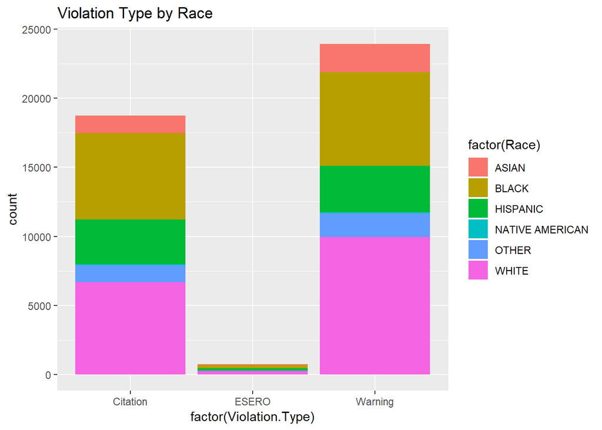

```r
a2 <- a + geom_bar(aes(fill = factor(Race))) + ggtitle("Violation Type by Race")

a2
```

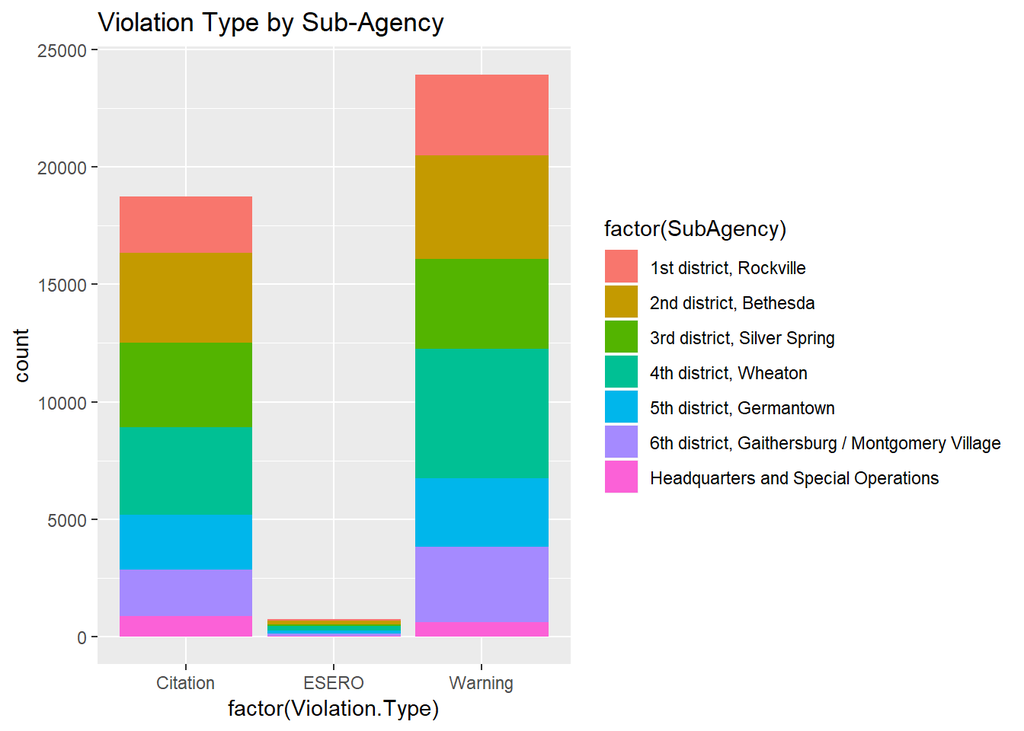

```r
a3 <- a + geom_bar(aes(fill = factor(SubAgency))) + ggtitle("Violation Type by Sub-Agency")
a3
```

## Percentage of different race in certain violation category

```r
library(dplyr)
library(scales)
library(expss)
percentage_tbl <- data.frame(cro(TV4$Violation.Type, list(TV4$Race)))


percentage_tbl <- mutate(percentage_tbl, Total_Violations = rowSums(percentage_tbl[,2:7])) %>%
                                 mutate(BLACK = percent(BLACK/Total_Violations))  %>%
                                 mutate(HISPANIC = percent(HISPANIC/Total_Violations)) %>%
                                 mutate(NATIVE.AMERICAN = percent(NATIVE.AMERICAN/Total_Violations)) %>%
                                 mutate(OTHER = percent(OTHER/Total_Violations)) %>%
                                 mutate(WHITE = percent(WHITE/Total_Violations))%>%
                                 mutate(ASIAN = percent(ASIAN/Total_Violations))

percentage_tbl <- percentage_tbl[1:4,]
Violation_type <- c("Citation","ESERO","SERO","Warning")
percentage_tbl['Violation_Type'] <- Violation_type
percentage_tbl <- percentage_tbl[,2:9]
percentage_tbl <- percentage_tbl[c(8,1:7)]
percentage_tbl
```

```
##   Violation_Type ASIAN  BLACK HISPANIC NATIVE.AMERICAN OTHER WHITE
## 1       Citation 6.74% 33.38%    17.4%          0.219% 6.62% 35.6%
## 2          ESERO 8.87% 29.20%    25.9%          0.682% 3.96% 31.4%
## 3           SERO   NA%    NA%      NA%             NA%   NA%   NA%
## 4        Warning 8.63% 28.24%    14.1%          0.288% 7.19% 41.6%
##   Total_Violations
## 1            18753
## 2              733
## 3               NA
## 4            23956
```

# Pre-regression Tests

## Avoid Multicollinearity

In order to avoid multicollinearity among independent variables, we need to visualize the correlation through a correlation map. We exlucede variables that have almost 0 standard deviations (such as fatal, which are pre-dominantly 0s, and hardly any 1s).

```r
library(corrplot)
heat.data <- TV3[, c(2,7,10, 13:19,21,22)]
heat.data <-  heat.data[sample(nrow(heat.data), 1000), ]
res <- cor(heat.data)
round(res, 2)
```

```
##                    Belts Commercial.License vio_type_warning
## Belts               1.00               0.00            -0.07
## Commercial.License  0.00               1.00            -0.06
## vio_type_warning   -0.07              -0.06             1.00
## vio_type_citation   0.08               0.06            -0.97
## Black               0.02               0.07             0.03
## White               0.00              -0.02             0.00
## Hispanic           -0.07               0.01            -0.05
## Native_American    -0.02              -0.01            -0.01
## Asian               0.08              -0.03             0.03
## Other_race         -0.03              -0.05            -0.02
## Male               -0.01               0.05            -0.02
## Female              0.01              -0.05             0.02
##                    vio_type_citation Black White Hispanic Native_American
## Belts                           0.08  0.02  0.00    -0.07           -0.02
## Commercial.License              0.06  0.07 -0.02     0.01           -0.01
## vio_type_warning               -0.97  0.03  0.00    -0.05           -0.01
## vio_type_citation               1.00 -0.04  0.00     0.04            0.01
## Black                          -0.04  1.00 -0.54    -0.24           -0.04
## White                           0.00 -0.54  1.00    -0.36           -0.06
## Hispanic                        0.04 -0.24 -0.36     1.00           -0.03
## Native_American                 0.01 -0.04 -0.06    -0.03            1.00
## Asian                          -0.02 -0.18 -0.26    -0.12           -0.02
## Other_race                      0.02 -0.16 -0.24    -0.11           -0.02
## Male                            0.02  0.05 -0.09     0.03           -0.01
## Female                         -0.02 -0.05  0.09    -0.03            0.01
##                    Asian Other_race  Male Female
## Belts               0.08      -0.03 -0.01   0.01
## Commercial.License -0.03      -0.05  0.05  -0.05
## vio_type_warning    0.03      -0.02 -0.02   0.02
## vio_type_citation  -0.02       0.02  0.02  -0.02
## Black              -0.18      -0.16  0.05  -0.05
## White              -0.26      -0.24 -0.09   0.09
## Hispanic           -0.12      -0.11  0.03  -0.03
## Native_American    -0.02      -0.02 -0.01   0.01
## Asian               1.00      -0.07  0.01  -0.01
## Other_race         -0.07       1.00  0.04  -0.04
## Male                0.01       0.04  1.00  -1.00
## Female             -0.01      -0.04 -1.00   1.00
```

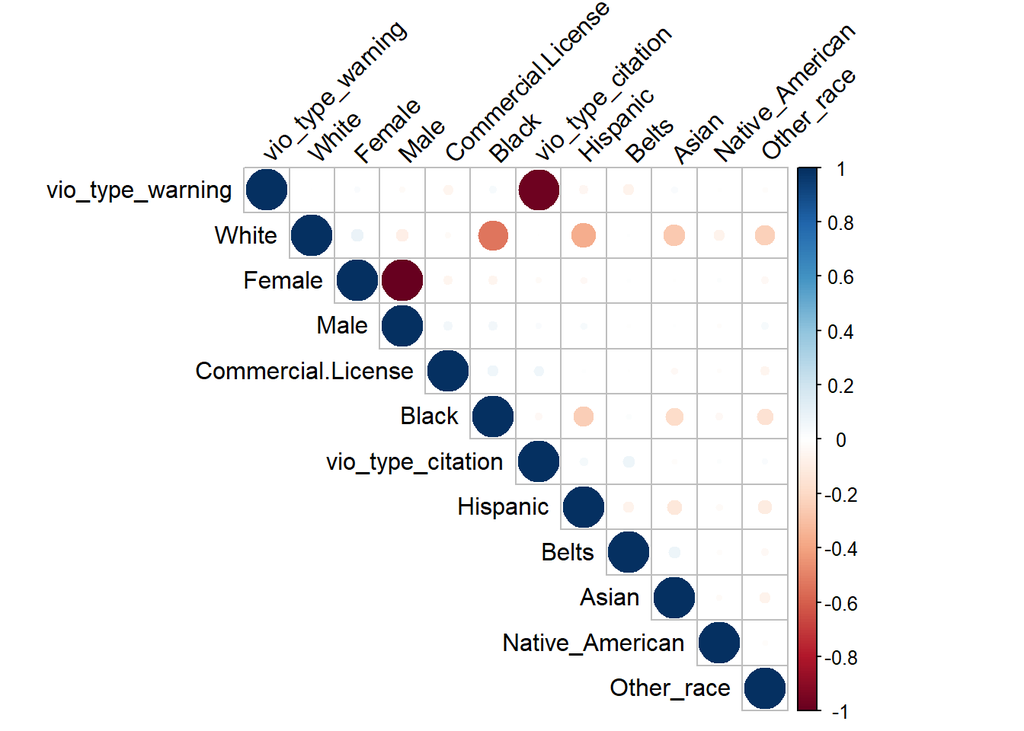

```r
corrplot(res, type = "upper", order = "hclust",
         tl.col = "black", tl.srt = 45)
```

## Chi-squared tests

Null hypothesis (H0): the violation type and race are independent. Alternative hypothesis (H1): the violation type and race are dependent

```r
library(reshape2)
# https://rpubs.com/biomanoos/balloonplot
contingency_tbl <- data.frame(cro(TV4$Violation.Type, list(TV4$Race)))
contingency_tbl <- contingency_tbl[1:4,]
Violation_type <- c("Citation","ESERO","SERO","Warning")
contingency_tbl['Violation_Type'] <- Violation_type
contingency_tbl <- contingency_tbl[,2:8]
contingency_tbl <- contingency_tbl[c(7,1:6)]
# Delete row 3 since it contains NAs (if I replace it with 0 the chi-square test will through an error)
contingency_tbl <- contingency_tbl[c(1,2,4),]
contingency_tbl
```

```
##   Violation_Type ASIAN BLACK HISPANIC NATIVE.AMERICAN OTHER WHITE
## 1       Citation  1264  6259     3272              41  1241  6676
## 2          ESERO    65   214      190               5    29   230
## 4        Warning  2068  6764     3372              69  1722  9961
```

```r
matrix_con <- as.matrix(contingency_tbl[2:7])
matrix_con
```

```
##   ASIAN BLACK HISPANIC NATIVE.AMERICAN OTHER WHITE
## 1  1264  6259     3272              41  1241  6676
## 2    65   214      190               5    29   230
## 4  2068  6764     3372              69  1722  9961
```

```r
chisq.test(matrix_con)
```

```
## Warning in chisq.test(matrix_con): Chi-squared approximation may be
## incorrect
```

```
##
##  Pearson's Chi-squared test
##
## data:  matrix_con
## X-squared = 394.74, df = 10, p-value < 2.2e-16
```

As we can see above, the p-value is very low (well below 0.01), so we reject the null hypothses. In ohter words, the violation type and race are dependent.

# Logistic Regressions

In order to assess the impact of race and gender on the probability of receiving a warning, we regress the binary variable vio_type_warning (1: received a warning; 0: did not receive a warning) on the set of independent variables after deleting those which have a large vif score. I only display the final regression here, please refer to the appendix of this html file to see other regressions tested before the final one.

```r
library(faraway)
# should exclude Fatal, Alcohol and personal.injury, which have large vif
mylogit <- glm(vio_type_warning ~ Female + Black + Other_race + Hispanic + Asian + Native_American + Belts  + Property.Damage + Commercial.License + HAZMAT + SubAgency, data = TV3, family = "binomial")
summary(mylogit)
```

```
##
## Call:
## glm(formula = vio_type_warning ~ Female + Black + Other_race +
##     Hispanic + Asian + Native_American + Belts + Property.Damage +
##     Commercial.License + HAZMAT + SubAgency, family = "binomial",
##     data = TV3)
##
## Deviance Residuals:
##     Min       1Q   Median       3Q      Max
## -1.7108  -1.1957   0.8022   0.9593   2.3249
##
## Coefficients:
##                                                           Estimate
## (Intercept)                                               0.499043
## Female                                                    0.146946
## Black                                                    -0.144066
## Other_race                                               -0.071050
## Hispanic                                                 -0.289513
## Asian                                                    -0.006025
## Native_American                                           0.062806
## Belts                                                    -0.834225
## Property.Damage                                          -2.446824
## Commercial.License                                        0.087608
## HAZMAT                                                   -1.622737
## SubAgency2nd district, Bethesda                          -0.114211
## SubAgency3rd district, Silver Spring                      0.182352
## SubAgency4th district, Wheaton                            0.322826
## SubAgency5th district, Germantown                         0.007967
## SubAgency6th district, Gaithersburg / Montgomery Village  0.466680
## SubAgencyHeadquarters and Special Operations             -0.455167
##                                                          Std. Error
## (Intercept)                                                0.051696
## Female                                                     0.037592
## Black                                                      0.044954
## Other_race                                                 0.073421
## Hispanic                                                   0.055922
## Asian                                                      0.069129
## Native_American                                            0.303907
## Belts                                                      0.099074
## Property.Damage                                            0.184480
```

[output cut: 39 more lines]

```
## SubAgency3rd district, Silver Spring                     **
## SubAgency4th district, Wheaton                           ***
## SubAgency5th district, Germantown
## SubAgency6th district, Gaithersburg / Montgomery Village ***
## SubAgencyHeadquarters and Special Operations             ***
## ---
## Signif. codes:  0 '***' 0.001 '**' 0.01 '*' 0.05 '.' 0.1 ' ' 1
##
## (Dispersion parameter for binomial family taken to be 1)
##
##     Null deviance: 17030  on 15645  degrees of freedom
## Residual deviance: 16485  on 15629  degrees of freedom
## AIC: 20668
##
## Number of Fisher Scoring iterations: 4
```

```r
vif(mylogit)
```

```
##                                                   Female
##                                                 4.515215
##                                                    Black
##                                                 5.722346
##                                               Other_race
##                                                 4.849999
##                                                 Hispanic
##                                                 5.181649
##                                                    Asian
##                                                 4.986889
##                                          Native_American
##                                                 4.542926
##                                                    Belts
##                                                 4.423882
##                                          Property.Damage
##                                                 8.616212
##                                       Commercial.License
##                                                 4.524059
##                                                   HAZMAT
##                                                 5.236317
##                          SubAgency2nd district, Bethesda
##                                                 8.616322
##                     SubAgency3rd district, Silver Spring
##                                                 8.605267
##                           SubAgency4th district, Wheaton
##                                                 8.836042
##                        SubAgency5th district, Germantown
##                                                 7.447722
## SubAgency6th district, Gaithersburg / Montgomery Village
##                                                 7.572208
##             SubAgencyHeadquarters and Special Operations
##                                                 5.257195
```

In order for the regression coefficient to be unbiased estimates, we assume that there are no omitted variable bias, which implies we’ve included all the relevent variables in our model. I know this assumption may not be true, but due to limited data, we can assume it is true for now and interpret the coefficient under such assumption.

From the regression above, we can observe that our baseline group is white male, whose probability of receiving a warning is captured in the intercept term. All the coefficients should be interpreted as the natural log of odds of receiving a warning. Below is a chart of translating logodds to probability of receiving a warning (https://stats.idre.ucla.edu/other/mult-pkg/faq/general/faq-how-do-i-interpret-odds-ratios-in-logistic-regression/):

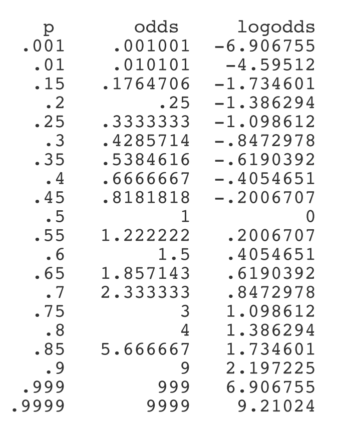

A positive logodds coefficient means the group is more likely to get a warning versus not getting a warning. Within the significant coefficients, we can see that white male and female are more likely to get a warning versus not, while being black and hispanic would be less likely to get a warning.

```r
# should exclude Alcohol, Fatal and personal.injury, which have large vif

mylogit <- glm(vio_type_citation ~ Female + Black + Other_race + Hispanic + Asian + Native_American + Belts + Property.Damage + Commercial.License + HAZMAT + SubAgency, data = TV3, family = "binomial")
```

```
## Warning in eval(family$initialize): non-integer #successes in a binomial
## glm!
```

```r
summary(mylogit)
```

```
##
## Call:
## glm(formula = vio_type_citation ~ Female + Black + Other_race +
##     Hispanic + Asian + Native_American + Belts + Property.Damage +
##     Commercial.License + HAZMAT + SubAgency, family = "binomial",
##     data = TV3)
##
## Deviance Residuals:
##     Min       1Q   Median       3Q      Max
## -2.3357  -0.9284  -0.7838   1.0989   1.7743
##
## Coefficients:
##                                                           Estimate
## (Intercept)                                              -0.557122
## Female                                                   -0.116519
## Black                                                     0.105694
## Other_race                                                0.075965
## Hispanic                                                  0.198435
## Asian                                                     0.002313
## Native_American                                          -0.178154
## Belts                                                     0.858781
## Property.Damage                                           2.501153
## Commercial.License                                       -0.081255
## HAZMAT                                                    1.762200
## SubAgency2nd district, Bethesda                           0.074072
## SubAgency3rd district, Silver Spring                     -0.167096
## SubAgency4th district, Wheaton                           -0.349171
## SubAgency5th district, Germantown                        -0.028425
## SubAgency6th district, Gaithersburg / Montgomery Village -0.490145
## SubAgencyHeadquarters and Special Operations              0.464555
##                                                          Std. Error
## (Intercept)                                                0.052098
## Female                                                     0.037997
## Black                                                      0.045455
## Other_race                                                 0.074038
## Hispanic                                                   0.056701
## Asian                                                      0.069800
## Native_American                                            0.312007
## Belts                                                      0.098967
## Property.Damage                                            0.182665
```

[output cut: 39 more lines]

```
## SubAgency3rd district, Silver Spring                     **
## SubAgency4th district, Wheaton                           ***
## SubAgency5th district, Germantown
## SubAgency6th district, Gaithersburg / Montgomery Village ***
## SubAgencyHeadquarters and Special Operations             ***
## ---
## Signif. codes:  0 '***' 0.001 '**' 0.01 '*' 0.05 '.' 0.1 ' ' 1
##
## (Dispersion parameter for binomial family taken to be 1)
##
##     Null deviance: 16804  on 15645  degrees of freedom
## Residual deviance: 16255  on 15629  degrees of freedom
## AIC: 19246
##
## Number of Fisher Scoring iterations: 4
```

```r
vif(mylogit)
```

```
##                                                   Female
##                                                 4.613032
##                                                    Black
##                                                 5.850780
##                                               Other_race
##                                                 4.931917
##                                                 Hispanic
##                                                 5.326912
##                                                    Asian
##                                                 5.084168
##                                          Native_American
##                                                 4.788319
##                                                    Belts
##                                                 4.414374
##                                          Property.Damage
##                                                 8.447510
##                                       Commercial.License
##                                                 4.639757
##                                                   HAZMAT
##                                                 5.310181
##                          SubAgency2nd district, Bethesda
##                                                 8.754992
##                     SubAgency3rd district, Silver Spring
##                                                 8.737369
##                           SubAgency4th district, Wheaton
##                                                 9.044505
##                        SubAgency5th district, Germantown
##                                                 7.577584
## SubAgency6th district, Gaithersburg / Montgomery Village
##                                                 7.786571
##             SubAgencyHeadquarters and Special Operations
##                                                 5.277112
```

The logistic regressions using violation types ESERO as dependent variable is as follows. Since the data points in ESER category is too few compared to citations and warnings, I will exclude SubAgency from independent variables.

```r
mylogit <- glm(vio_type_ESERO ~ Female + Black + Other_race + Hispanic + Asian + Native_American + Belts + Alcohol + Personal.Injury + Property.Damage + Fatal + Commercial.License + HAZMAT, data = TV3, family = "binomial")
```

```
## Warning in eval(family$initialize): non-integer #successes in a binomial
## glm!
```

```r
summary(mylogit)
```

```
##
## Call:
## glm(formula = vio_type_ESERO ~ Female + Black + Other_race +
##     Hispanic + Asian + Native_American + Belts + Alcohol + Personal.Injury +
##     Property.Damage + Fatal + Commercial.License + HAZMAT, family = "binomial",
##     data = TV3)
##
## Deviance Residuals:
##     Min       1Q   Median       3Q      Max
## -0.3003  -0.2280  -0.1851  -0.1534   3.0364
##
## Coefficients:
##                      Estimate Std. Error z value Pr(>|z|)
## (Intercept)        -4.058e+00  1.201e-01 -33.797  < 2e-16 ***
## Female             -4.088e-01  1.387e-01  -2.947  0.00321 **
## Black               4.209e-01  1.565e-01   2.690  0.00714 **
## Other_race         -9.595e-02  3.002e-01  -0.320  0.74923
## Hispanic            9.172e-01  1.679e-01   5.464 4.66e-08 ***
## Asian              -3.013e-03  2.753e-01  -0.011  0.99127
## Native_American     9.818e-01  7.630e-01   1.287  0.19817
## Belts              -3.567e-01  4.226e-01  -0.844  0.39861
## Alcohol            -1.840e+01  7.861e+02  -0.023  0.98133
## Personal.Injury    -3.341e+00  2.715e+00  -1.231  0.21841
## Property.Damage    -1.646e+00  1.024e+00  -1.607  0.10801
## Fatal              -2.077e+01  1.494e+03  -0.014  0.98891
## Commercial.License -8.897e-02  4.153e-01  -0.214  0.83037
## HAZMAT             -1.797e+01  1.375e+03  -0.013  0.98957
## ---
## Signif. codes:  0 '***' 0.001 '**' 0.01 '*' 0.05 '.' 0.1 ' ' 1
##
## (Dispersion parameter for binomial family taken to be 1)
##
##     Null deviance: 2437.3  on 15645  degrees of freedom
## Residual deviance: 2378.8  on 15632  degrees of freedom
## AIC: 1893.9
##
## Number of Fisher Scoring iterations: 14
```

```r
vif(mylogit)
```

```
##             Female              Black         Other_race
##       6.149236e+01       6.931811e+01       8.105586e+01
##           Hispanic              Asian    Native_American
##       4.668725e+01       7.911460e+01       2.863481e+01
##              Belts            Alcohol    Personal.Injury
##       8.050118e+01       2.654854e+06       1.383552e+03
##    Property.Damage              Fatal Commercial.License
##       2.655226e+02       2.791255e+06       5.154114e+01
##             HAZMAT
##       2.571613e+06
```

A negative logodds coefficient means the group is less likely to get a ESERO versus not getting a ESERO. Within the significant coefficients, we can see that white male and female are less likely to get a ESERO, while being black and hispanic would be more likely to get a ESERO.

Since we do not have any data points for SERO violation in year 2015, we cannot conduct regression analysis on that dependent variable.

# Appendix

## Other regressions tested before reaching the final one

```r
mylogit <- glm(vio_type_warning ~ Female + Black + Other_race + Hispanic + Asian + Native_American + Belts + Alcohol + Personal.Injury + Property.Damage + Fatal + Commercial.License + HAZMAT + SubAgency, data = TV3, family = "binomial")
summary(mylogit)
```

```
##
## Call:
## glm(formula = vio_type_warning ~ Female + Black + Other_race +
##     Hispanic + Asian + Native_American + Belts + Alcohol + Personal.Injury +
##     Property.Damage + Fatal + Commercial.License + HAZMAT + SubAgency,
##     family = "binomial", data = TV3)
##
## Deviance Residuals:
##     Min       1Q   Median       3Q      Max
## -1.7283  -1.1323   0.7875   0.9460   2.5982
##
## Coefficients:
##                                                           Estimate
## (Intercept)                                                0.52293
## Female                                                     0.16047
## Black                                                     -0.15690
## Other_race                                                -0.08143
## Hispanic                                                  -0.30022
## Asian                                                     -0.01325
## Native_American                                            0.02598
## Belts                                                     -0.72368
## Alcohol                                                   -3.72004
## Personal.Injury                                           -2.98288
## Property.Damage                                           -2.48312
## Fatal                                                    -20.94895
## Commercial.License                                         0.09795
## HAZMAT                                                    -1.64807
## SubAgency2nd district, Bethesda                           -0.09808
## SubAgency3rd district, Silver Spring                       0.18613
## SubAgency4th district, Wheaton                             0.32842
## SubAgency5th district, Germantown                          0.02604
## SubAgency6th district, Gaithersburg / Montgomery Village   0.45772
## SubAgencyHeadquarters and Special Operations              -0.47303
##                                                          Std. Error
## (Intercept)                                                 0.05212
## Female                                                      0.03797
## Black                                                       0.04533
## Other_race                                                  0.07399
## Hispanic                                                    0.05636
## Asian                                                       0.06974
```

[output cut: 51 more lines]

```
## SubAgency3rd district, Silver Spring                     **
## SubAgency4th district, Wheaton                           ***
## SubAgency5th district, Germantown
## SubAgency6th district, Gaithersburg / Montgomery Village ***
## SubAgencyHeadquarters and Special Operations             ***
## ---
## Signif. codes:  0 '***' 0.001 '**' 0.01 '*' 0.05 '.' 0.1 ' ' 1
##
## (Dispersion parameter for binomial family taken to be 1)
##
##     Null deviance: 17030  on 15645  degrees of freedom
## Residual deviance: 16226  on 15626  degrees of freedom
## AIC: 20426
##
## Number of Fisher Scoring iterations: 10
```

```r
vif(mylogit)
```

```
##                                                   Female
##                                                 4.605544
##                                                    Black
##                                                 5.819167
##                                               Other_race
##                                                 4.925870
##                                                 Hispanic
##                                                 5.262768
##                                                    Asian
##                                                 5.076087
##                                          Native_American
##                                                 4.546393
##                                                    Belts
##                                                 4.670547
##                                                  Alcohol
##                                                21.340237
##                                          Personal.Injury
##                                                13.092636
##                                          Property.Damage
##                                                 8.608606
##                                                    Fatal
##                                             46042.894289
##                                       Commercial.License
##                                                 4.623814
##                                                   HAZMAT
##                                                 5.260356
##                          SubAgency2nd district, Bethesda
##                                                 8.766894
##                     SubAgency3rd district, Silver Spring
##                                                 8.733196
##                           SubAgency4th district, Wheaton
##                                                 8.978521
##                        SubAgency5th district, Germantown
##                                                 7.590176
## SubAgency6th district, Gaithersburg / Montgomery Village
##                                                 7.668858
##             SubAgencyHeadquarters and Special Operations
##                                                 5.288097
```

```r
mylogit <- glm(vio_type_citation ~ Female + Black + Other_race + Hispanic + Asian + Native_American + Belts + Alcohol + Personal.Injury + Property.Damage + Fatal + Commercial.License + HAZMAT + SubAgency, data = TV3, family = "binomial")
summary(mylogit)
```

```
##
## Call:
## glm(formula = vio_type_citation ~ Female + Black + Other_race +
##     Hispanic + Asian + Native_American + Belts + Alcohol + Personal.Injury +
##     Property.Damage + Fatal + Commercial.License + HAZMAT + SubAgency,
##     family = "binomial", data = TV3)
##
## Deviance Residuals:
##     Min       1Q   Median       3Q      Max
## -2.5979  -0.9182  -0.7703   1.0220   1.7704
##
## Coefficients:
##                                                            Estimate
## (Intercept)                                               -0.581874
## Female                                                    -0.130306
## Black                                                      0.118708
## Other_race                                                 0.086975
## Hispanic                                                   0.208472
## Asian                                                      0.009995
## Native_American                                           -0.139715
## Belts                                                      0.744556
## Alcohol                                                    3.867263
## Personal.Injury                                            3.058404
## Property.Damage                                            2.539108
## Fatal                                                     21.177456
## Commercial.License                                        -0.092645
## HAZMAT                                                     1.789781
## SubAgency2nd district, Bethesda                            0.056409
## SubAgency3rd district, Silver Spring                      -0.171011
## SubAgency4th district, Wheaton                            -0.355744
## SubAgency5th district, Germantown                         -0.047874
## SubAgency6th district, Gaithersburg / Montgomery Village  -0.481194
## SubAgencyHeadquarters and Special Operations               0.483209
##                                                          Std. Error
## (Intercept)                                                0.052552
## Female                                                     0.038405
## Black                                                      0.045871
## Other_race                                                 0.074655
## Hispanic                                                   0.057197
## Asian                                                      0.070467
```

[output cut: 51 more lines]

```
## SubAgency3rd district, Silver Spring                     **
## SubAgency4th district, Wheaton                           ***
## SubAgency5th district, Germantown
## SubAgency6th district, Gaithersburg / Montgomery Village ***
## SubAgencyHeadquarters and Special Operations             ***
## ---
## Signif. codes:  0 '***' 0.001 '**' 0.01 '*' 0.05 '.' 0.1 ' ' 1
##
## (Dispersion parameter for binomial family taken to be 1)
##
##     Null deviance: 16804  on 15645  degrees of freedom
## Residual deviance: 15978  on 15626  degrees of freedom
## AIC: 18949
##
## Number of Fisher Scoring iterations: 10
```

```r
vif(mylogit)
```

```
##                                                   Female
##                                                 4.712579
##                                                    Black
##                                                 5.958405
##                                               Other_race
##                                                 5.014406
##                                                 Hispanic
##                                                 5.420468
##                                                    Asian
##                                                 5.181806
##                                          Native_American
##                                                 4.791598
##                                                    Belts
##                                                 4.676066
##                                                  Alcohol
##                                                21.416744
##                                          Personal.Injury
##                                                13.043022
##                                          Property.Damage
##                                                 8.439034
##                                                    Fatal
##                                             45792.321722
##                                       Commercial.License
##                                                 4.750744
##                                                   HAZMAT
##                                                 5.338565
##                          SubAgency2nd district, Bethesda
##                                                 8.921504
##                     SubAgency3rd district, Silver Spring
##                                                 8.876545
##                           SubAgency4th district, Wheaton
##                                                 9.203231
##                        SubAgency5th district, Germantown
##                                                 7.734834
## SubAgency6th district, Gaithersburg / Montgomery Village
##                                                 7.894123
##             SubAgencyHeadquarters and Special Operations
##                                                 5.309982
```

```r
mylogit <- glm(vio_type_ESERO ~ Female + Black + Other_race + Hispanic + Asian + Native_American + Belts + Alcohol + Personal.Injury + Property.Damage + Fatal + Commercial.License + HAZMAT, data = TV3, family = "binomial")
summary(mylogit)
```

```
##
## Call:
## glm(formula = vio_type_ESERO ~ Female + Black + Other_race +
##     Hispanic + Asian + Native_American + Belts + Alcohol + Personal.Injury +
##     Property.Damage + Fatal + Commercial.License + HAZMAT, family = "binomial",
##     data = TV3)
##
## Deviance Residuals:
##     Min       1Q   Median       3Q      Max
## -0.3003  -0.2280  -0.1851  -0.1534   3.0364
##
## Coefficients:
##                      Estimate Std. Error z value Pr(>|z|)
## (Intercept)        -4.058e+00  1.201e-01 -33.797  < 2e-16 ***
## Female             -4.088e-01  1.387e-01  -2.947  0.00321 **
## Black               4.209e-01  1.565e-01   2.690  0.00714 **
## Other_race         -9.595e-02  3.002e-01  -0.320  0.74923
## Hispanic            9.172e-01  1.679e-01   5.464 4.66e-08 ***
## Asian              -3.013e-03  2.753e-01  -0.011  0.99127
## Native_American     9.818e-01  7.630e-01   1.287  0.19817
## Belts              -3.567e-01  4.226e-01  -0.844  0.39861
## Alcohol            -1.840e+01  7.861e+02  -0.023  0.98133
## Personal.Injury    -3.341e+00  2.715e+00  -1.231  0.21841
## Property.Damage    -1.646e+00  1.024e+00  -1.607  0.10801
## Fatal              -2.077e+01  1.494e+03  -0.014  0.98891
## Commercial.License -8.897e-02  4.153e-01  -0.214  0.83037
## HAZMAT             -1.797e+01  1.375e+03  -0.013  0.98957
## ---
## Signif. codes:  0 '***' 0.001 '**' 0.01 '*' 0.05 '.' 0.1 ' ' 1
##
## (Dispersion parameter for binomial family taken to be 1)
##
##     Null deviance: 2437.3  on 15645  degrees of freedom
## Residual deviance: 2378.8  on 15632  degrees of freedom
## AIC: 1893.9
##
## Number of Fisher Scoring iterations: 14
```

```r
vif(mylogit)
```

```
##             Female              Black         Other_race
##       6.149236e+01       6.931811e+01       8.105586e+01
##           Hispanic              Asian    Native_American
##       4.668725e+01       7.911460e+01       2.863481e+01
##              Belts            Alcohol    Personal.Injury
##       8.050118e+01       2.654854e+06       1.383552e+03
##    Property.Damage              Fatal Commercial.License
##       2.655226e+02       2.791255e+06       5.154114e+01
##             HAZMAT
##       2.571613e+06
```